# Clustering of Image Colors

2026-02-23

## Introduction

This exercise demonstrates several aspects of numerical taxonomy as applied to a three-band image, in this case a photograph. A similar workflow could be applied to a stack of DEM and climate surface derivatives. After working through this exercise, use a different photograph of approximately the same image dimensions.

## Background

Paraphrased from *Numerical Taxonomy (Sneath and Sokal, 1973)*.

1. What is a good classification?
2. Is classification “A” better than classification “B”?
3. How similar are two classifications?
4. Is there significant structure in a set of operational taxonomic units (pixels, soil profiles, climate stations, etc.)?
5. Do two or more clusters, delineated by prior procedure, differ in their newly observed properties?
6. Do two or more clusters, delineated by numerical taxonomy, differ in any of the properties on which they were clustered?

## Objectives

In this example we will apply ideas from the [Numerical Taxonomy / Ordination](http://ncss-tech.github.io/stats_for_soil_survey/book2/numerical-tax.html) module to a photograph. These methods can also be applied to a stack of terrain/climate derivatives for the purposes of initial or update soil survey work. The basic work-flow looks something like this:

- load stack of conformal grids: same coordinate reference system, grid size, grid extent
- exhaustive sampling of grids (random, regular, etc.) at points
- sub-sample points via cLHS
- compute distance matrix
- apply clustering algorithms
- visualize: dendrogram (if possible), nMDS, etc.
- evaluate optimal number of clusters for PAM-style clustering (silhouette width scree plot)
- evaluate goodness of nMDS solution (stress scree plot and Shepard diagram)
- fit simple model (LDA, etc.) to predict cluster ID at every pixel in the stack
- make predictions: class membership and most-likely class
- visualize predictions as an image
- evaluate class-wise uncertainty with Shannon entropy
- estimate nMDS scores for each pixel of the example image

Several parts of this demonstration depend on functions that have a non-deterministic outcome:

- cLHS-sampling via `clhs::clhs()`
- nMDS via `MASS::sammon()`
- partitioning around medoids clustering via `cluster::pam()`

In order to create repeatable results, the following examples use the `set.seed()` function to control randomness. This can be a useful trick when it is necessary to generate the same output each time a report or analysis is run. However, one should not use `set.seed()` when a truly random outcome is required.

### Planned additions

- evaluation of full vs. sampled data-space

## Setup

Load packages that we will be using.

```r
library(aqp)
library(terra)
library(cluster)
library(ape)
library(farver)
library(MASS)
library(colorspace)
library(clhs)
```

Use an image with well-defined colors to demonstrate methods / syntax.

```r
# I like airplanes
# URL to example image, you can swap out for any image you like
# be sure to coordinate the image URL and file extension
url <- 'https://github.com/ncss-tech/stats_for_soil_survey/raw/master/exercises/numerical-taxonomy/photo.jpg'
tf <- tempfile(fileext = '.jpg')

# download, this may fail if you are on the VPN
download.file(url, destfile = tf, mode = 'wb')

# or, point to local file that can be read by GDAL:
# tf <- 'photo.jpg'

# load as 3-band SpatRast object
# bands: red, green, blue (sRGB color space)
r <- rast(tf, noflip = TRUE)

# optionally, use your own image or stack of GIS data
# r <- rast(...)
```

Inspect the resulting `SpatRast` object.

```r
# re-name bands for access later
names(r) <- c('r', 'g', 'b')

# object properties
print(r)
```

```
## class       : SpatRaster
## size        : 640, 628, 3  (nrow, ncol, nlyr)
## resolution  : 1, 1  (x, y)
## extent      : 0, 628, 0, 640  (xmin, xmax, ymin, ymax)
## coord. ref. :
## source      : filef8c3b9a6307.jpg
## colors RGB  : 1, 2, 3
## names       : r, g, b
```

Display 3-band stack as an RGB image.

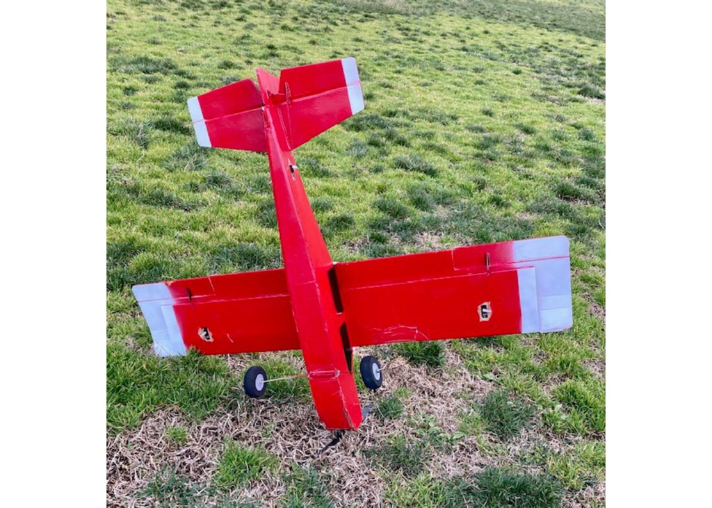

Example image, a red model airplane leaning on the propellor, against a background of patchy green and light green grass.

```r
plotRGB(r)
```

## Color Conversion

Convert to [CIELAB](https://en.wikipedia.org/wiki/CIELAB_color_space) color space, much more useful for analysis of color. I’ll abbreviate CIELAB as LAB for simplicity.

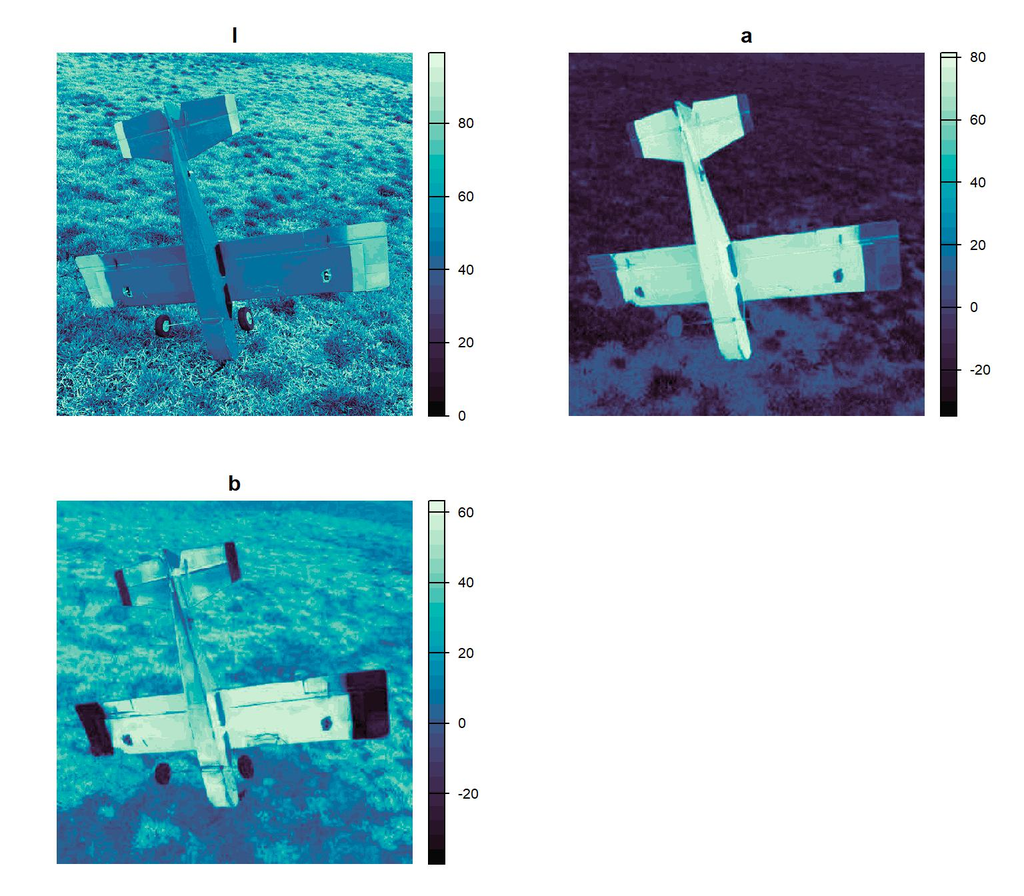

Example image split into CIELAB color coordinates.

```r
# copy SpatRast / update with LAB color coordinates
r.lab <- r

# simple trick to directly access / replace values of a SpatRast
values(r.lab) <- convert_colour(values(r), from = 'rgb', to = 'lab', white_from = 'D65')
names(r.lab) <- c('l', 'a', 'b')

# check
# bands are L, A, B color space coordinates
# positive "A" coordinates are "red"
plot(r.lab, col = hcl.colors(25, palette = 'mako'), axes = FALSE)
```

## Sampling

Exhaustive sampling, extracting LAB color coordinates.

```r
s <- spatSample(r.lab, size = 5000, method = 'regular', as.points = TRUE)
```

Sub-sample using cLHS algorithm. Much easier to compute distance matrix from a small, representative sample.

```r
# note temporary conversion to sf object
# required by clhs()
# result is an integer index to samples
set.seed(42)
idx <- clhs(sf::st_as_sf(s), size = 250)
```

Visual check on cLHS-selected samples (blue).

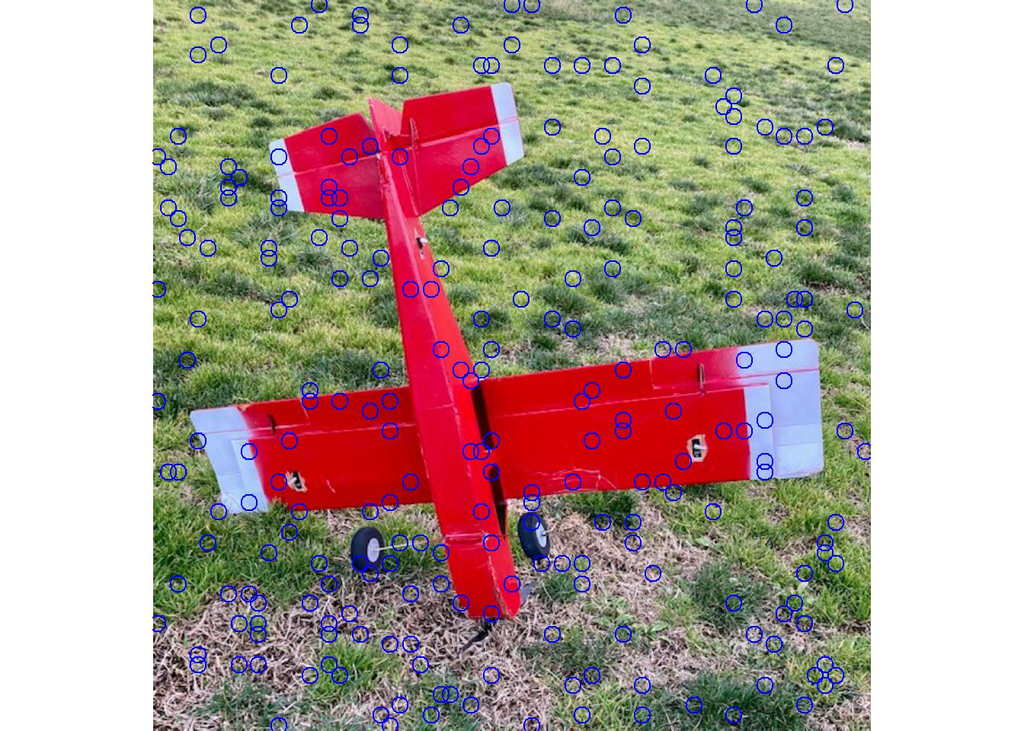

Example image, with clhs-defined sampling points.

```r
plotRGB(r, axes = FALSE)
# points(s, pch = 3, col = 'white', cex = 0.25)
points(s[idx, ], pch = 1, col = 'blue', cex = 1.5)
```

Note that that there are very few samples covering the (black) windows and wheels.

Visualize color space coordinates.

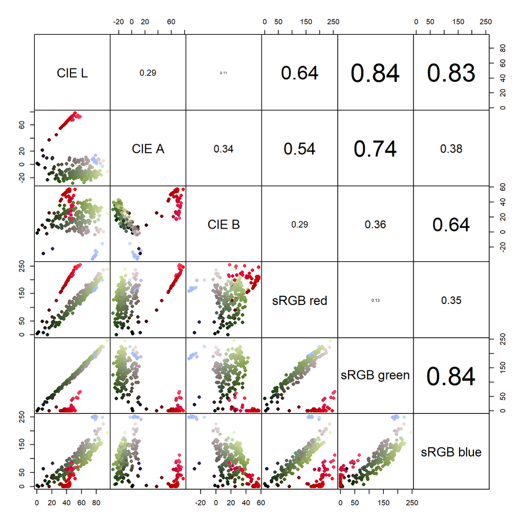

Scatter plot matrix of CIELAB and sRGB color space coordinates, at sampling points, symbolized using image colors. Pearson correlation coefficients are printed in the upper triangle of the matrix.

```r
# keep only the cLHS samples
s <- s[idx, ]

# convert SpatVect -> data.frame
s.lab <- as.data.frame(s)

## convert CIE LAB values extracted at smples -> sRGB
s.rgb <- convert_colour(s.lab[, c('l', 'a', 'b')], from = 'lab', to = 'rgb', white_from = 'D65')

# convert to R colors, hex notation
s.cols <- rgb(s.rgb, maxColorValue = 255)


# helper function for paired scatterplot,
# see ?pairs for further examples
panel.cor <- function(x, y, digits = 2, prefix = "", cex.cor, ...) {
    par(usr = c(0, 1, 0, 1))
    r <- abs(cor(x, y))
    txt <- format(c(r, 0.123456789), digits = digits)[1]
    txt <- paste0(prefix, txt)
    if(missing(cex.cor)) {
      cex.cor <- 0.8 / strwidth(txt)
    }
    text(0.5, 0.5, txt, cex = cex.cor * r)
}

# 6-variable scatter plot matrix
# CIELAB color space coordinates
# sRGB color space coordinates
pairs(
  cbind(
    s.lab[, c('l', 'a', 'b')],
    s.rgb[, c('r', 'g', 'b')]
  ),
  pch = 16,
  col = s.cols,
  labels = c('CIE L', 'CIE A', 'CIE B', 'sRGB red', 'sRGB green', 'sRGB blue'),
  upper.panel = panel.cor,
  gap = 0
)
```

## Distance Matrix

Compute pair-wise distances via *Δ**E*<sub>00</sub> [color contrast metric](https://en.wikipedia.org/wiki/Color_difference).

```r
## compute pair-wise distances
# using the CIE2000 color contrast metric
# perceptual (avg. human vision) vs. Euclidean distance
d <- compare_colour(
  from = s.lab[, c('l', 'a', 'b')],
  to = s.lab[, c('l', 'a', 'b')],
  from_space = 'lab',
  method = 'CIE2000'
)

# convert full-matrix form to simpler 'dist' representation
d <- as.dist(d)

# check for 0 distances, can cause problems for nMDS
summary(d)
```

```
##    Min. 1st Qu.  Median    Mean 3rd Qu.    Max.
##  0.2061 17.0882 31.8117 32.6391 48.0050 95.4191
```

```r
# if there are any, set those to a small value
d[which(d == 0)] <- quantile(d[which(d > 0)], prob = 0.001, na.rm = TRUE)
```

## Ordination by nMDS

There are many implementations of non-metric multidimensional scaling; [Sammon’s Non-Linear Mapping](https://en.wikipedia.org/wiki/Sammon_mapping) is a good place to start.

Recall that an ordination is a projection of the high-dimensionality distance matrix to a small number of dimensions, usually 2 or 3. This projection incurs a loss of fidelity. A [scree plot](https://en.wikipedia.org/wiki/Scree_plot) is a qualitative way to visually determine a reasonable number of dimensions required for a given distance matrix. Look for the “elbow” in the scree plot for a reasonable starting point.

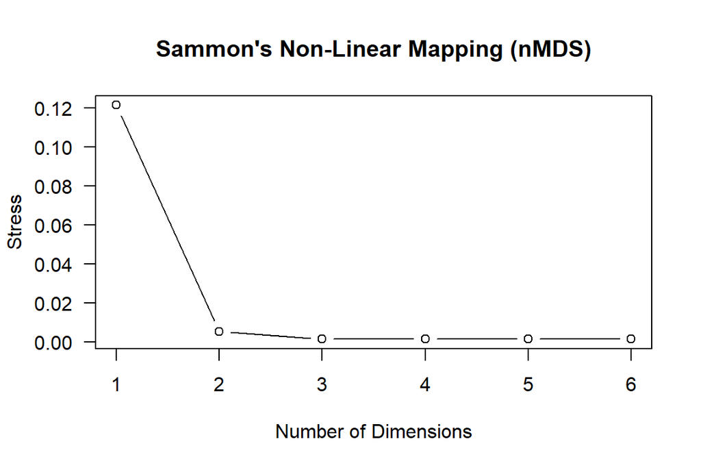

Scree plot of nMDS stress values as a function of ordination rank.

```r
.seq <- 1:6
.stress <- sapply(.seq, function(i) {
  .res <- sammon(d, k = i)$stress
})

plot(x = .seq, y = .stress, type = "b", las = 1, ylab = "Stress", xlab = 'Number of Dimensions', main = "Sammon's Non-Linear Mapping (nMDS)")
```

In this case, it would appear that 2 dimensions are sufficient.

Generate an nMDS solution for our distance matrix. Output is always slightly different, unless controlling the randomness via `set.seed()`.

```r
# "fixed" randomness,
# only important when you want the same result every time
set.seed(42)

mds <- sammon(d)
```

```
## Initial stress        : 0.01528
## stress after  10 iters: 0.00552, magic = 0.500
## stress after  20 iters: 0.00542, magic = 0.500
## stress after  30 iters: 0.00541, magic = 0.500
```

```r
# check resulting structure
str(mds)
```

```
## List of 3
##  $ points: num [1:250, 1:2] -9.05 -6.38 -19.84 -22.11 -14.61 ...
##   ..- attr(*, "dimnames")=List of 2
##   .. ..$ : NULL
##   .. ..$ : NULL
##  $ stress: num 0.00541
##  $ call  : language sammon(d = d)
```

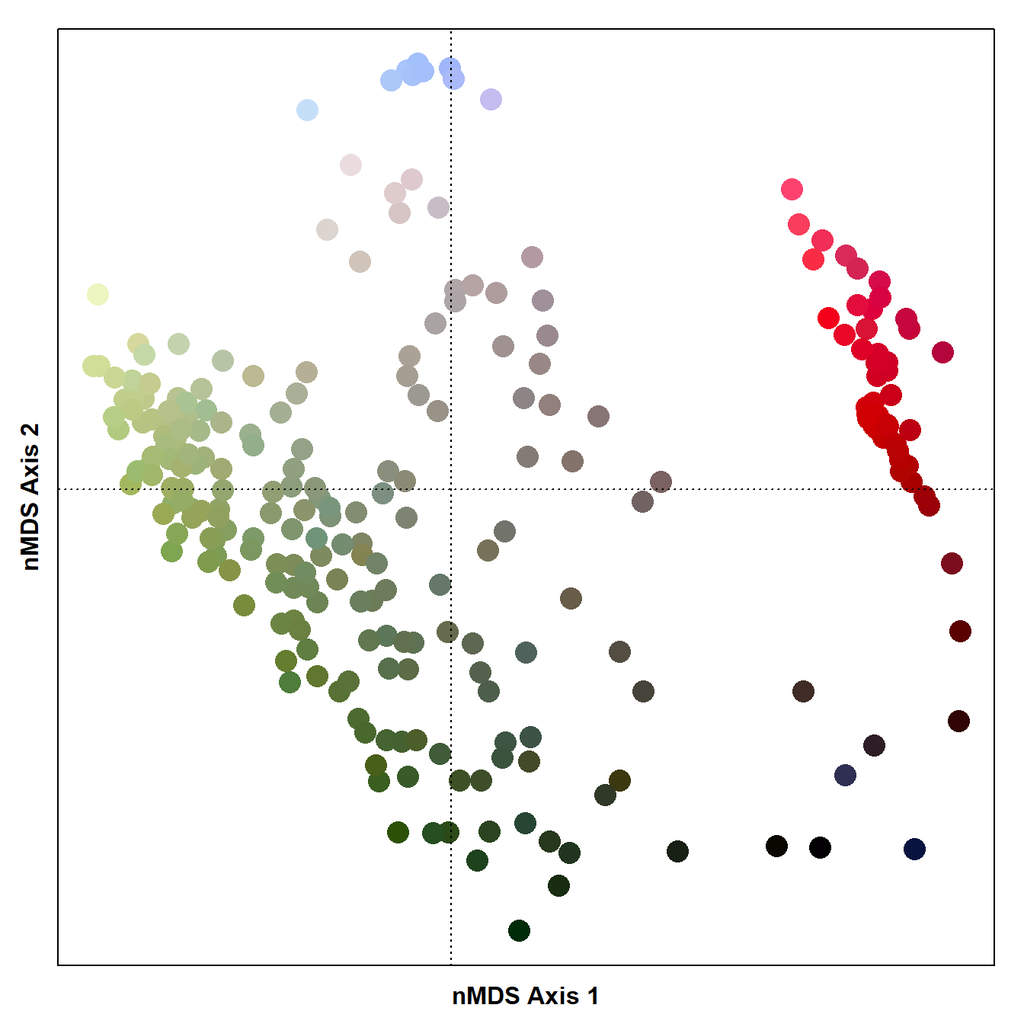

Ordination by nMDS.

```r
# simple visualization of nMDS ordination
# colors from sRGB color coordinates, converted to hex notation
par(mar = c(2, 2, 1, 1))
plot(mds$points, pch = 16, col = s.cols, cex = 2, axes = FALSE)
# add horizontal / vertical lines to see "origin" of nMDS coordinates
abline(h = 0, v = 0, lty = 3)
box()
mtext('nMDS Axis 1', side = 1, line = 0.5, font = 2)
mtext('nMDS Axis 2', side = 2, line = 0.5, font = 2)
```

Shepard plot. For more options, see related functions from the [vegan package](https://rdrr.io/rforge/vegan/man/goodness.metaMDS.html).

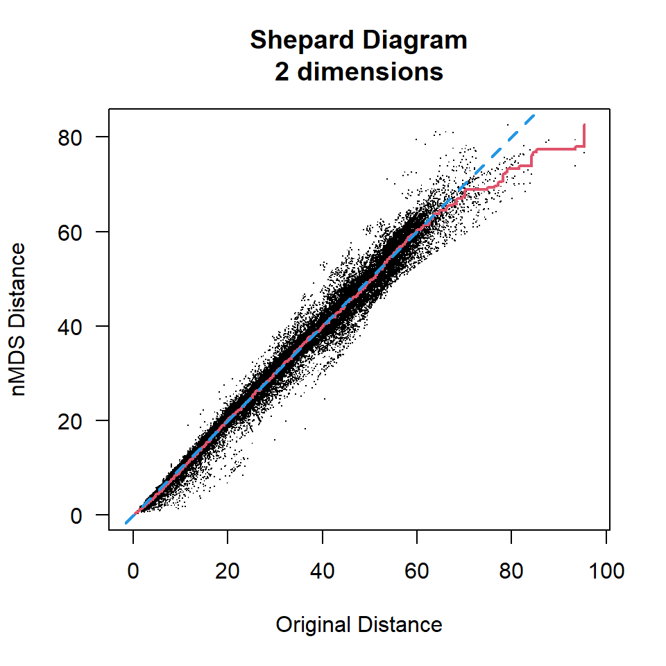

Shepard plot for ordination above. Values close to the 1:1 line (dashed blue line) indicate a reasonable ordination solution.

```r
# generate data for Shepard Diagram
shep <- Shepard(d, mds$points)

plot(shep, pch = ".", asp = 1, xlab = 'Original Distance', ylab = 'nMDS Distance', main = 'Shepard Diagram\n2 dimensions', las = 1)
lines(shep$x, shep$yf, type = "S", col = 2, lwd = 2)
abline(0, 1, col = 4, lty = 2, lwd = 2)
```

See nMDS-eval-01 for additional examples.

## Cluster Analysis

### Divisive Hierarchical Clustering

Note that the `hclust` object is often used as a common format when converting from one object class to another. For example, converting the divisive hierarchical clustering object created by `diana()` to `phylo` class requires a trip through the `hclust` format.

```r
# divisive hierarchical clustering of distance matrix
dd <- diana(d)

# convert cluster pkg object -> hclust obj. -> phylo obj.
h <- as.phylo(as.hclust(dd))

# attempt rotation of the dendrogram leaves
# using rank-order from the first nMDS axis above
h <- rotateConstr(h, constraint = order(mds$points[, 1]))
```

Using the `plot` method for `phylo` class objects, as provided by the ape package.

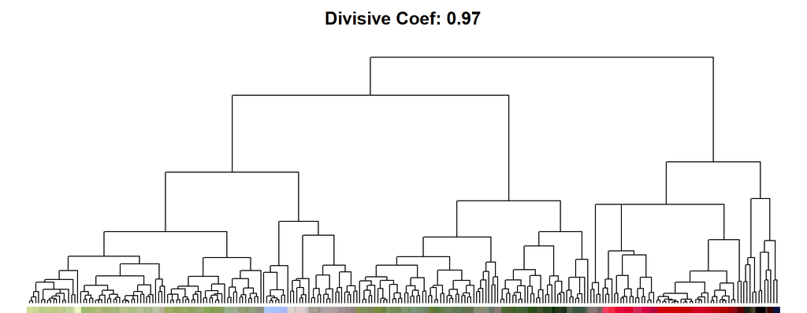

Dendrogram representation of pair-wise distances, after divisive hierarchical clustering.

```r
par(mar = c(0, 0, 2, 0))

plot(
  h,
  show.tip.label = FALSE,
  direct = 'down',
  type = 'phylogram',
  y.lim = c(0, 50),
  main = sprintf("Divisive Coef: %s", round(dd$dc, 2))
)

# make a block of tip label colors
# using repeated calls, varying vertical offsets
tiplabels(pch = 15, col = s.cols, offset = 1.5)
tiplabels(pch = 15, col = s.cols, offset = 2.5)
tiplabels(pch = 15, col = s.cols, offset = 3.5)
```

### K-medoids Clustering

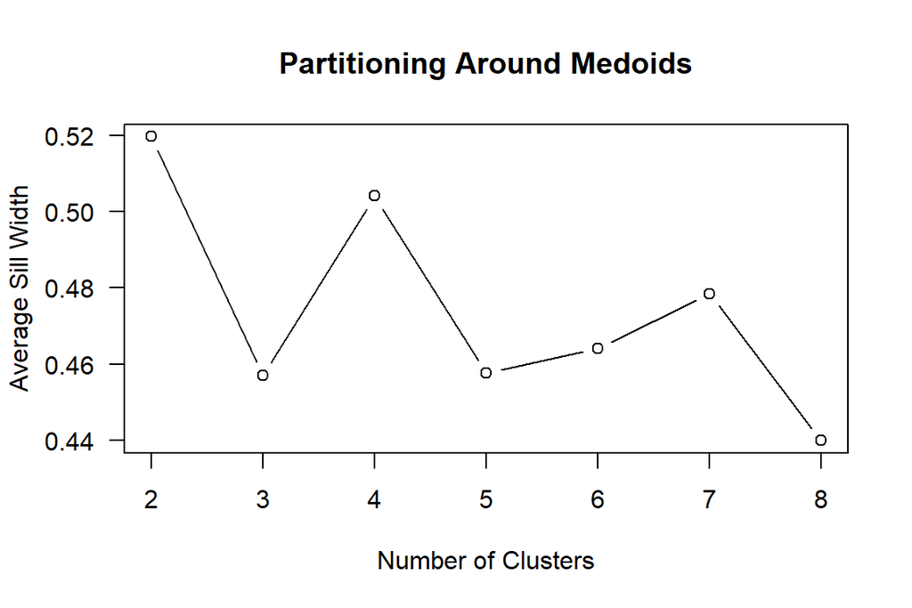

Scree plot of average sill width vs. number of clusters.

```r
# sequence of candidate clusters
.seq <- 2:8
# iterate over requested clusters
# retain avg. sill width metric
.silwidth <- sapply(.seq, function(i) {
  pam(d, k = i, diss = TRUE)$silinfo$avg.width
})

plot(x = .seq, y = .silwidth, type = "b", las = 1, ylab = "Average Sill Width", xlab = 'Number of Clusters', main = "Partitioning Around Medoids")
```

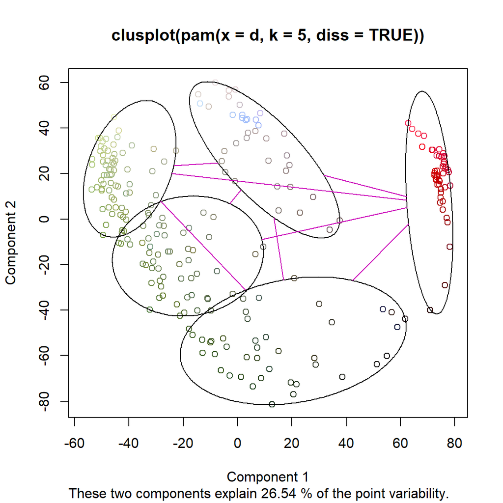

Cluster arrangement as visualized on axes of first and second principal components.

```r
# partitioning around medoids
# using the distance matrix vs. data matrix (diss = TRUE)
set.seed(42)
cl <- pam(d, k = 5, diss = TRUE)

# save clustering vector, these are integers
# interpret as categories
s.lab$cl <- factor(cl$clustering)

# plot method for partioning-style clustering (cluster package)
clusplot(cl, col.p = s.cols, plotchar = FALSE, col.clus = 'black')
```

Extract medoid colors in sRGB color space (for viewing on the screen).

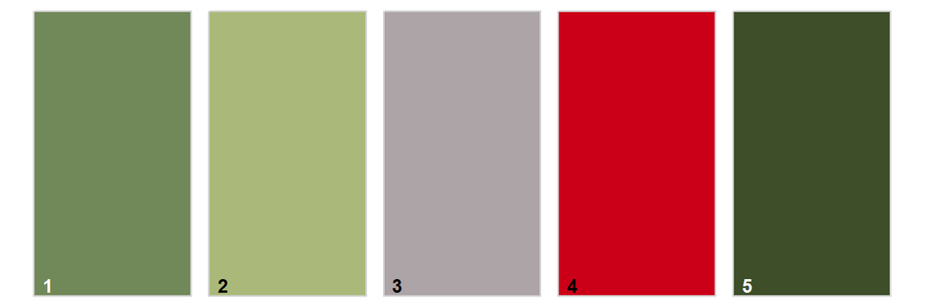

Color swatches of medoid colors.

```r
# cl$medoids is an index to the original data matrix
# will use these later
medoid.cols <- rgb(s.rgb[cl$medoids, ], maxColorValue = 255)

# quick check on medoid colors
par(mar = c(0, 0, 0, 0))
# using aqp::soilPalette() for convenience
soilPalette(medoid.cols, lab = 1:length(medoid.cols))
```

Visualize PAM clustering structure via previous ordination solution.

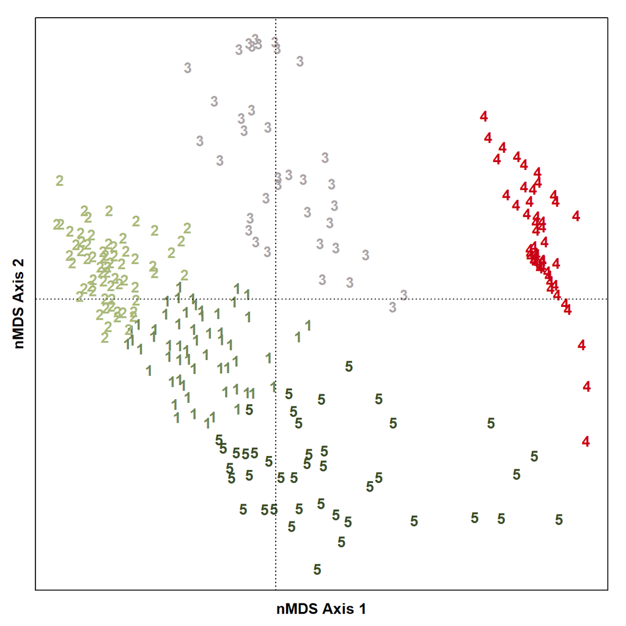

PAM clusters arranged by nMDS ordination.

```r
# simple visualization of nMDS ordination
# colors based on PAM medoid colors
par(mar = c(2, 2, 1, 1))
plot(mds$points, axes = FALSE, type = 'n')
text(mds$points, labels = cl$clustering, col = medoid.cols[cl$clustering], cex = 1, font = 2)
# add horizontal / vertical lines to see "origin" of nMDS coordinates
abline(h = 0, v = 0, lty = 3)
box()
mtext('nMDS Axis 1', side = 1, line = 0.5, font = 2)
mtext('nMDS Axis 2', side = 2, line = 0.5, font = 2)
```

## Supervised Classification

Supervised classification to interpolate between point samples, using linear discriminant analysis.

```r
# linear discriminant analysis (LDA) model works well here
# simple and efficient
m <- lda(cl ~ l + a + b, data = s.lab)
```

Demonstrate prediction output from `lda` object using some of the training data. The result is a `list`:

- `class` is the most likely class, as a factor
- `posterior` are the class-wise probabilities, as a matrix
- `x` are the LDA “scores” (not used here)

```r
# use only the first 6 rows of data
p <- predict(m, newdata = s.lab[1:6, ])

p$class
```

```
## [1] 1 1 2 2 1 2
## Levels: 1 2 3 4 5
```

```r
round(p$posterior, 3)
```

```
##       1     2     3 4     5
## 1 0.923 0.013 0.000 0 0.064
## 2 0.940 0.020 0.003 0 0.037
## 3 0.075 0.924 0.001 0 0.000
## 4 0.034 0.964 0.002 0 0.000
## 5 0.668 0.328 0.004 0 0.000
## 6 0.057 0.941 0.002 0 0.000
```

Linear discriminant function scatter plot matrix.

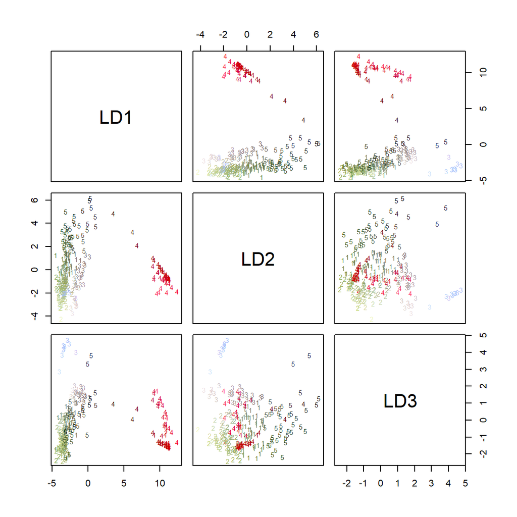

```r
plot(m, col = s.cols, fig.alt='Scatter plot matrix of linear discriminant scores.', fig.cap='Scatter plot matrix of linear discriminant scores.')
```

Wrapper functions around `predict` method used by LDA models, as applied to multi-band `spatRaster` objects.

```r
# prediction for most-likely class
pred.class <- function(model, data) {
  predict(model, data)$class
}

# class probabilities
pred.pr <- function(model, data) {
  predict(model, data)$posterior
}
```

Predict over entire stack (3-band) of LAB color coordinates.

```r
# most-likely cluster
p.class <- predict(r.lab, m, fun = pred.class)

# cluster probabilities
p.pr <- predict(r.lab, m, fun = pred.pr)
```

## Cluster Images (Maps)

Most-likely cluster (by pixel), followed by individual cluster probabilities.

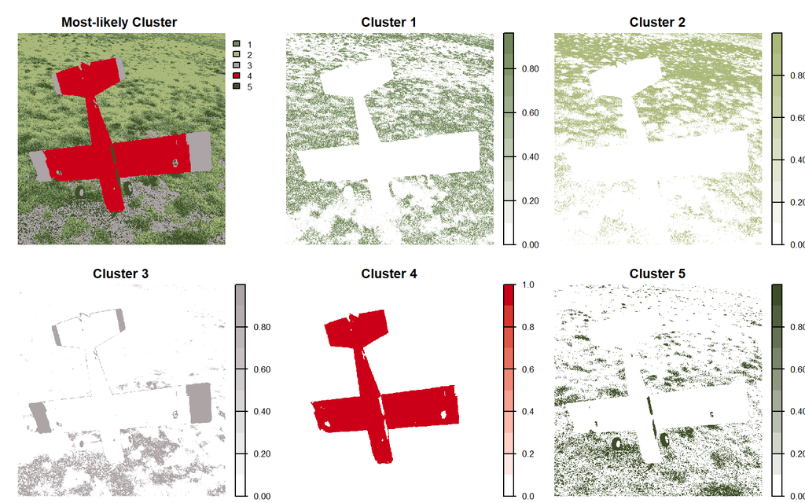

Clustering vector and class-wise probabilities for all pixels of the example image.

```r
par(mfrow = c(2, 3))

# most-likely cluster
plot(p.class, col = medoid.cols, axes = FALSE, main = 'Most-likely Cluster ', mar = c(0.5, 0.1, 2.5, 2))

for(i in 1:5) {

  # smooth color ramp
  # from white -> medoid color i
  cr <- colorRampPalette(c('white', medoid.cols[i]), space = 'Lab')

  plot(
    p.pr[[i]],
    col = cr(10),
    axes = FALSE,
    mar = c(0.5, 0.1, 2.5, 2),
    main = sprintf("Cluster %s", i)
  )
}
```

Shannon entropy (by pixel). Higher values suggest more uncertainty within predictions.

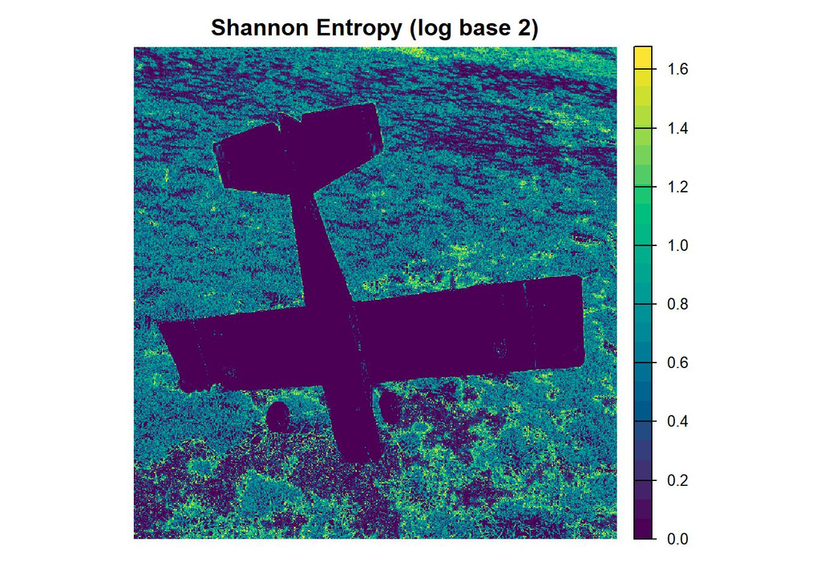

```r
# apply aqp::shannonEntropy() function at each stack of pixels
# stack represents predicted class-wise probability
H <- app(p.pr, shannonEntropy)

plot(H, col = hcl.colors(25), axes = FALSE, main = 'Shannon Entropy (log base 2)')
```

## nMDS Images (Maps)

Using multiple linear regression, we can estimate the nMDS scores for all pixels in the 3-band image.

```r
# row-order is preserved
# transfer nMDS scores to source data
# 250 sub-samples
s.lab$mds1 <- mds$points[, 1]
s.lab$mds2 <- mds$points[, 2]

# multiple linear regression of nMDS scores
# via CIE LAB color coordinates
lm.mds1 <- lm(mds1 ~ l + a + b, data = s.lab)
lm.mds2 <- lm(mds2 ~ l + a + b, data = s.lab)

# internal validation metrics, looks OK
summary(lm.mds1)
```

```
##
## Call:
## lm(formula = mds1 ~ l + a + b, data = s.lab)
##
## Residuals:
##     Min      1Q  Median      3Q     Max
## -7.1026 -1.2099 -0.3619  1.0750  5.1595
##
## Coefficients:
##              Estimate Std. Error t value Pr(>|t|)
## (Intercept) 31.136445   0.480439   64.81   <2e-16 ***
## l           -0.526332   0.007702  -68.34   <2e-16 ***
## a            0.525863   0.004772  110.20   <2e-16 ***
## b           -0.209590   0.007984  -26.25   <2e-16 ***
## ---
## Signif. codes:  0 '***' 0.001 '**' 0.01 '*' 0.05 '.' 0.1 ' ' 1
##
## Residual standard error: 2.16 on 246 degrees of freedom
## Multiple R-squared:  0.9893, Adjusted R-squared:  0.9892
## F-statistic:  7612 on 3 and 246 DF,  p-value: < 2.2e-16
```

```r
summary(lm.mds2)
```

```
##
## Call:
## lm(formula = mds2 ~ l + a + b, data = s.lab)
##
## Residuals:
##      Min       1Q   Median       3Q      Max
## -13.4890  -1.3130  -0.2117   1.5746   6.7099
##
## Coefficients:
##               Estimate Std. Error t value Pr(>|t|)
## (Intercept) -37.984215   0.541788  -70.11   <2e-16 ***
## l             0.766705   0.008685   88.28   <2e-16 ***
## a             0.383095   0.005381   71.19   <2e-16 ***
## b            -0.259294   0.009004  -28.80   <2e-16 ***
## ---
## Signif. codes:  0 '***' 0.001 '**' 0.01 '*' 0.05 '.' 0.1 ' ' 1
##
## Residual standard error: 2.436 on 246 degrees of freedom
## Multiple R-squared:  0.977,  Adjusted R-squared:  0.9767
## F-statistic:  3479 on 3 and 246 DF,  p-value: < 2.2e-16
```

```r
# spatial prediction
p.mds1 <- predict(r.lab, lm.mds1)
p.mds2 <- predict(r.lab, lm.mds2)
```

Attempt a simple interpretation of nMDS scores (axes).

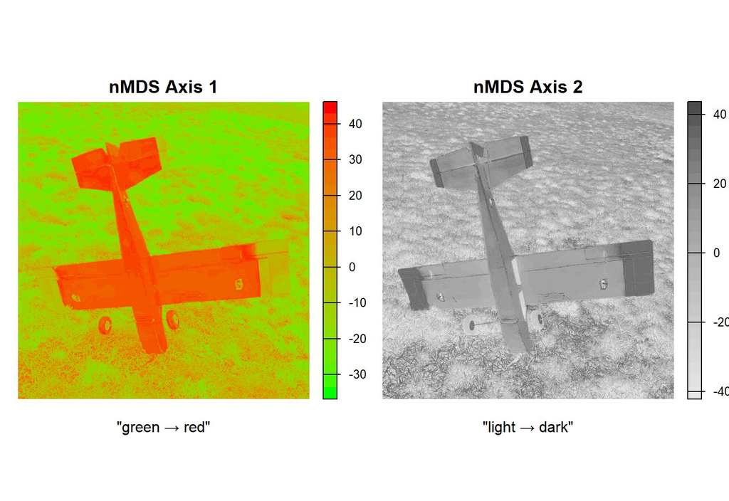

Images of nMDS scores, estimated at each pixel of the example image.

```r
# colors
mds1.cols <- colorRampPalette(c('green', 'red'), space = 'Lab')(25)
mds2.cols <- rev(grey.colors(25))

# maps
par(mfcol = c(1, 2))
plot(p.mds1, col = mds1.cols, axes = FALSE, main = 'nMDS Axis 1', mar = c(2, 1, 2, 3))
mtext(text = '"green \U2192 red"', side = 1, line = 0.5)

plot(p.mds2, col = mds2.cols, axes = FALSE, main = 'nMDS Axis 2', mar = c(2, 1, 2, 3))
mtext(text = '"light \U2192 dark"', side = 1, line = 0.5)
```